# Day 7 Practice

In this practice, let’s explore data on tipping, in the `tips` data frame from the `reshape2` package.

0. First get a little familiar with the structure of the data, using `summary()`, `head()`, etc. What are the numeric variables? What are their units? What about factors? Are factor levels sensible?

```r
library(reshape2)
library(tidyr)
```

```r
library(ggplot2)

mytips <- tips
head(tips)
```

```
##   total_bill  tip    sex smoker day   time size
## 1      16.99 1.01 Female     No Sun Dinner    2
## 2      10.34 1.66   Male     No Sun Dinner    3
## 3      21.01 3.50   Male     No Sun Dinner    3
## 4      23.68 3.31   Male     No Sun Dinner    2
## 5      24.59 3.61 Female     No Sun Dinner    4
## 6      25.29 4.71   Male     No Sun Dinner    4
```

1. Create a simple scatterplot, plotting the tip amount by the total bill.
- first plot the raw quantities
- “save” the initial simple plot as an object
- change the axis labels for both x and y
- try two different methods

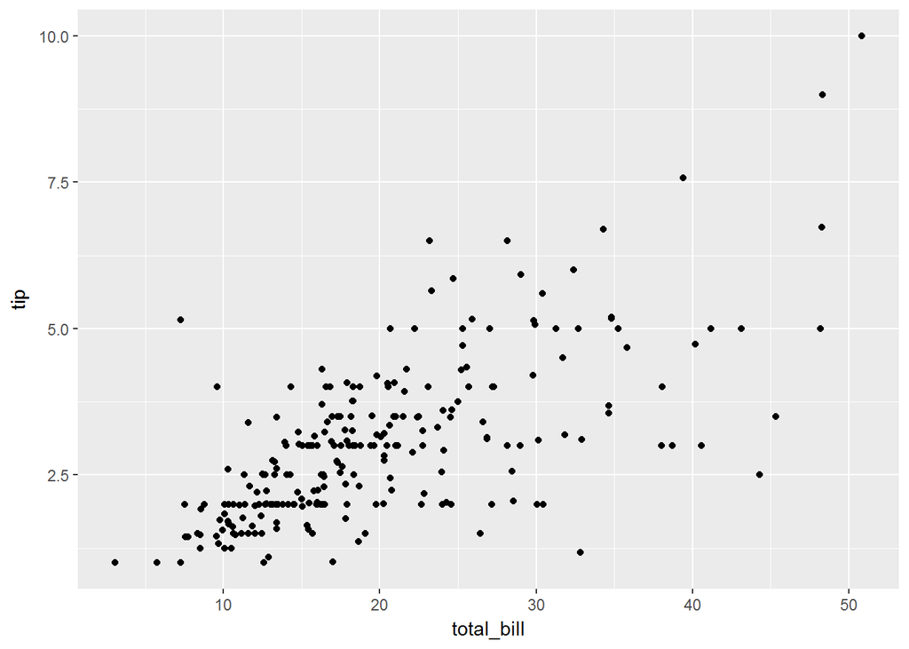

```r
ggplot(mytips, aes(x = total_bill, y = tip)) +
  geom_point()
```

2. Continue using the previous data
- using `scales`, plot the axes so that they follow a logarithmic pattern
- add “break” values every 5 dollars on the x axis, and every 2 dollars on the y axis
- finally, use `labels = dollar` (made available by the `scales` package) to format the axis numbers as dollars
3. Continue to build off of the final scatterplot in the previous problem (hint: you may need to change the plot object, in order to make the following changes)
- map gender to the color of the points
- change the color values, using both the “brewer” and “manual” methods
- add regression lines (regular linear regression), which also break down by gender
- also try a loess smoother instead of regression lines
- finally, change the overall “theme” to either the “classic”, “minimal”, or “bw” theme
4. Now let’s modify the legend for the `sex` variable, building off off the scatterplot with linear regression lines
- using the appropriate `scale` function, change the name of the legend to “Gender”
- change the location of the legend with the `theme()` function
- also using the “legend.position” argument, remove the legend completely
- finally, put the legend back to the default position, but change the levels, such that Male is given as the first level
5. Let’s explore how this pattern might vary for different days of the week.
- use faceting to create a separate plot for each day
- try both the “wrap” and “grid” faceting functions
- make a change so that the labels on the top of the facets give the full day name (e.g., “Friday”, not “Fri”), and they are ordered from Thursday to Sunday
6. Now let’s look at adding information about the size of the party to the plot
- first leave off the regression lines, to make it easier to see
- map party size to the size of the points
- look at both an aggregate plot and plots faceted by day
- now add back the regression lines, but only plot a single regression line (i.e., not broken down by gender), remove the confidence interval (hint: look at the arguments for `geom_smooth()`), and make the line a dashed black line